# HomeOffice_Main_Analysis

Marton Kovacs

21 July, 2020

# Install packages

```r
library(tidyverse)
```

# Source R scripts

```r
r_scripts <- list.files("R/", full.names = TRUE)
walk(r_scripts, source)
```

# Importing data

```r
processed <- read_tsv("Data/Main/Processed/HomeOffice_Main_Processed_data.tsv")
```

# Descriptives

## Number of respondents

There are 704 individual responses used for the analysis.

## Median time of responding to the survey

```r
processed %>%
  mutate(duration_in_seconds = as.integer(duration_in_seconds)) %>%
  summarise(median_resp = median(duration_in_seconds) / 60)
```

```
## # A tibble: 1 x 1
##   median_resp
##         <dbl>
## 1        5.09
```

## Response date range

```r
processed %>%
  mutate(recorded_date = lubridate::as_datetime(recorded_date)) %>%
  summarise(min_date = min(recorded_date),
            max_date = max(recorded_date))
```

```
## # A tibble: 1 x 2
##   min_date            max_date
##   <dttm>              <dttm>
## 1 2020-04-24 11:18:50 2020-07-13 20:38:53
```

## Gender distribution

```r
count(processed, gender)
```

```
## # A tibble: 4 x 2
##   gender                n
##   <chr>             <int>
## 1 Female              356
## 2 Male                338
## 3 Other                 1
## 4 Prefer not to say     9
```

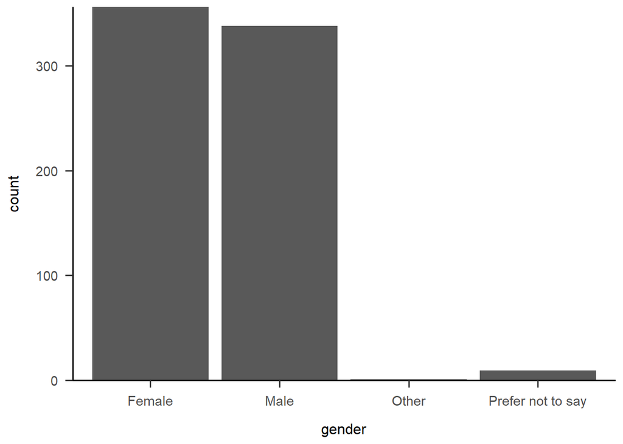

```r
apa_barplot(processed, gender)
```

## Disciplines

```r
count(processed, area_of_research)
```

```
## # A tibble: 6 x 2
##   area_of_research           n
##   <chr>                  <int>
## 1 Earth & Space Sciences     2
## 2 Formal Sciences            5
## 3 Life Sciences             98
## 4 Other                     63
## 5 Physical Sciences          5
## 6 Social Sciences          531
```

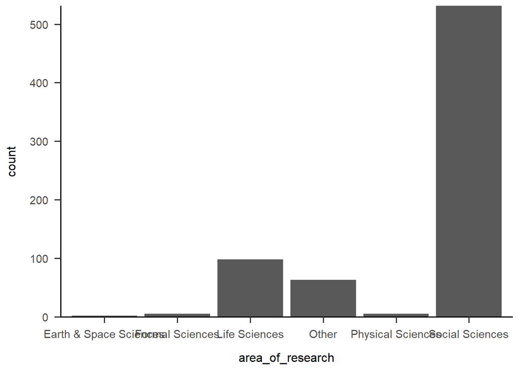

```r
apa_barplot(processed, area_of_research)
```

## Position

```r
count(processed, position)
```

```
## # A tibble: 7 x 2
##   position                    n
##   <chr>                   <int>
## 1 assistant professor       126
## 2 associate professor       172
## 3 full professor            209
## 4 non-academic researcher    38
## 5 PhD student                72
## 6 postdoc                    72
## 7 research assistant         15
```

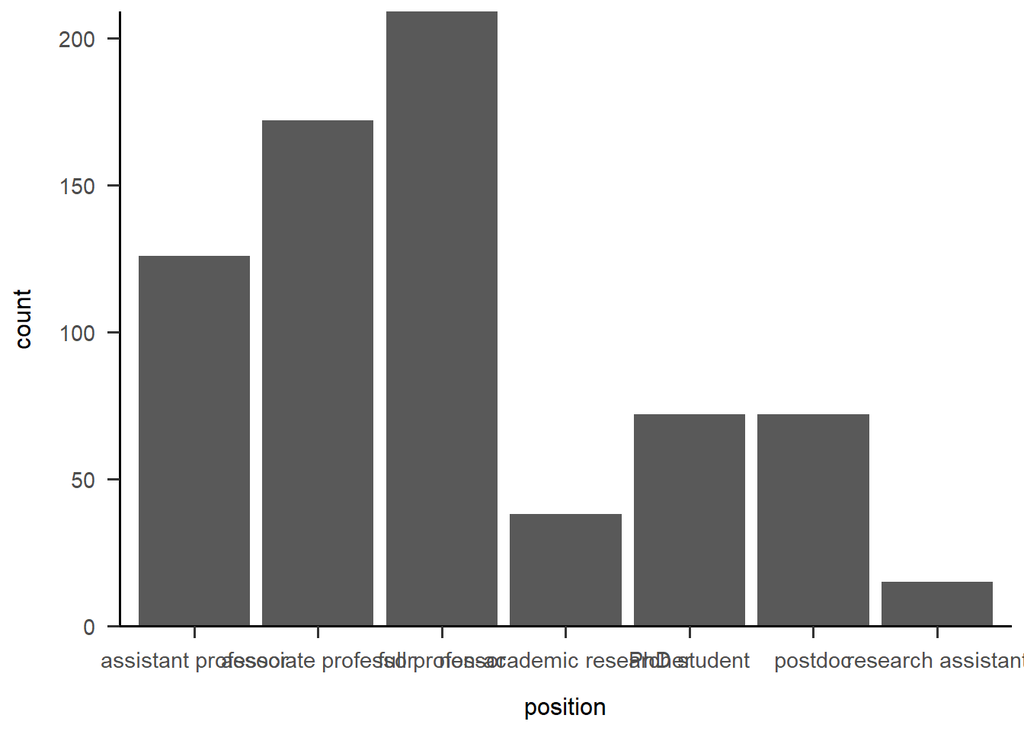

```r
apa_barplot(processed, position)
```

## Type of workplace

```r
count(processed, wokrplace_type)
```

```
## # A tibble: 4 x 2
##   wokrplace_type                         n
##   <chr>                              <int>
## 1 None of them                          21
## 2 Purely educational institute          14
## 3 Purely research institute             57
## 4 Research and educational institute   612
```

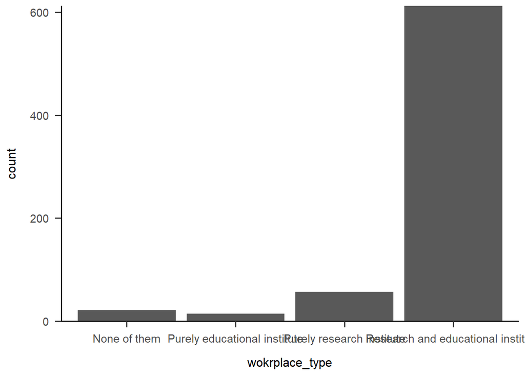

```r
apa_barplot(processed, wokrplace_type)
```

## Is it possible to collect data remotely

```r
count(processed, data_coll_remote)
```

```
## # A tibble: 3 x 2
##   data_coll_remote                                   n
##   <chr>                                          <int>
## 1 No                                               171
## 2 Yes (including if someone else does it for me)   512
## 3 <NA>                                              21
```

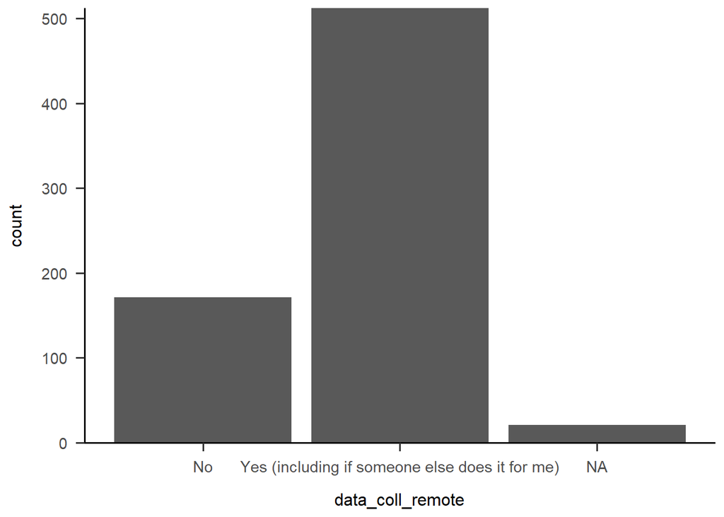

```r
apa_barplot(processed, data_coll_remote)
```

## Age group

```r
count(processed, age)
```

```
## # A tibble: 7 x 2
##   age          n
##   <chr>    <int>
## 1 25 - 34    150
## 2 35 - 44    231
## 3 45 - 54    169
## 4 55 - 64     93
## 5 65 - 74     48
## 6 75 - 84      6
## 7 Under 24     7
```

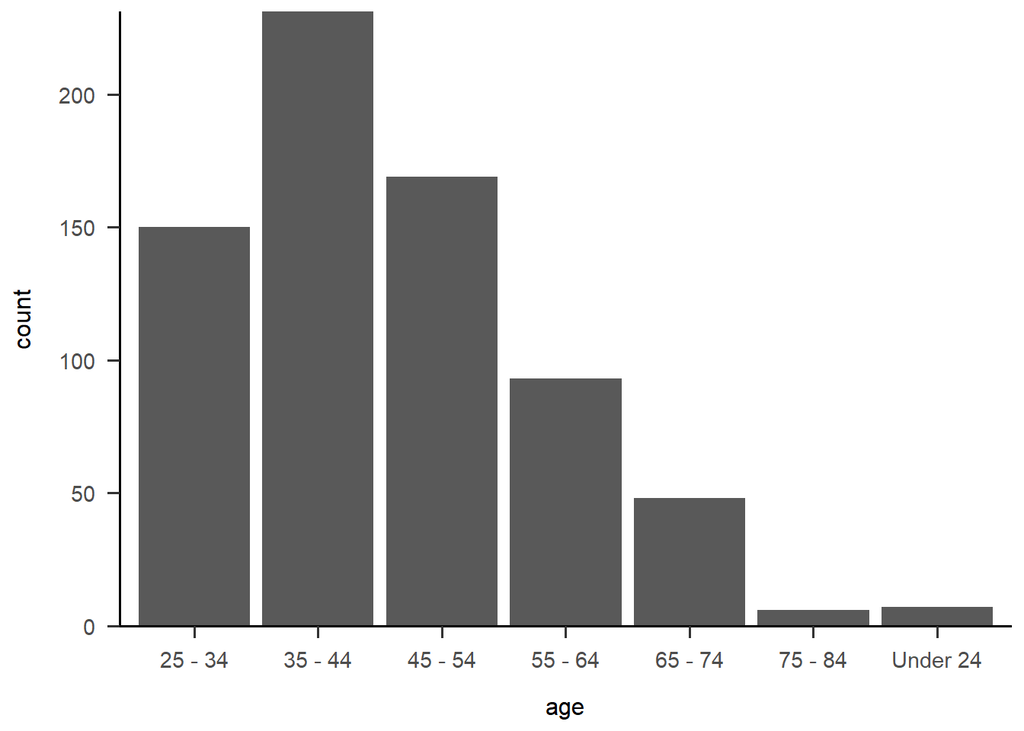

```r
apa_barplot(processed, age)
```

## Educational duties at work

```r
count(processed, edu_duties)
```

```
## # A tibble: 2 x 2
##   edu_duties     n
##   <chr>      <int>
## 1 No           138
## 2 Yes          566
```

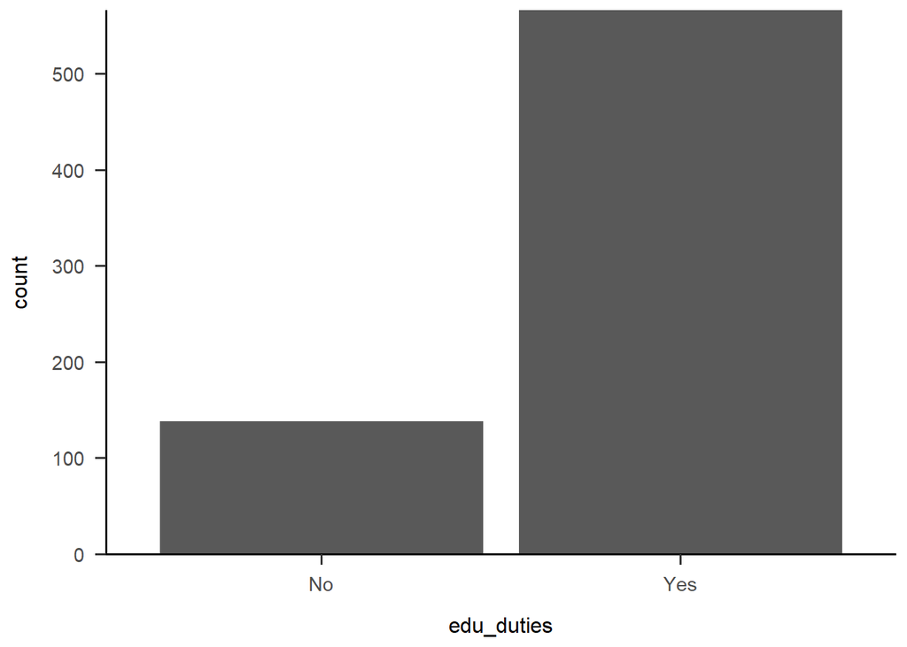

```r
apa_barplot(processed, edu_duties)
```

## Reasearch require intenvise teamwork

```r
count(processed, team_work)
```

```
## # A tibble: 2 x 2
##   team_work     n
##   <chr>     <int>
## 1 No          331
## 2 Yes         373
```

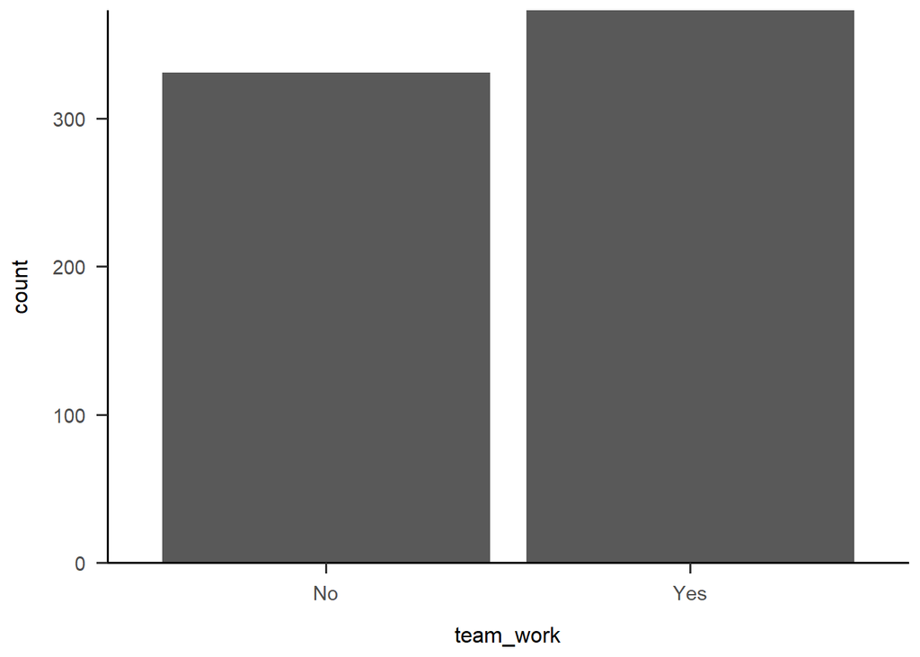

```r
apa_barplot(processed, team_work)
```

## Office setup at home

```r
count(processed, office_setup)
```

```
## # A tibble: 2 x 2
##   office_setup       n
##   <chr>          <int>
## 1 Fully equipped   444
## 2 Underequipped    260
```

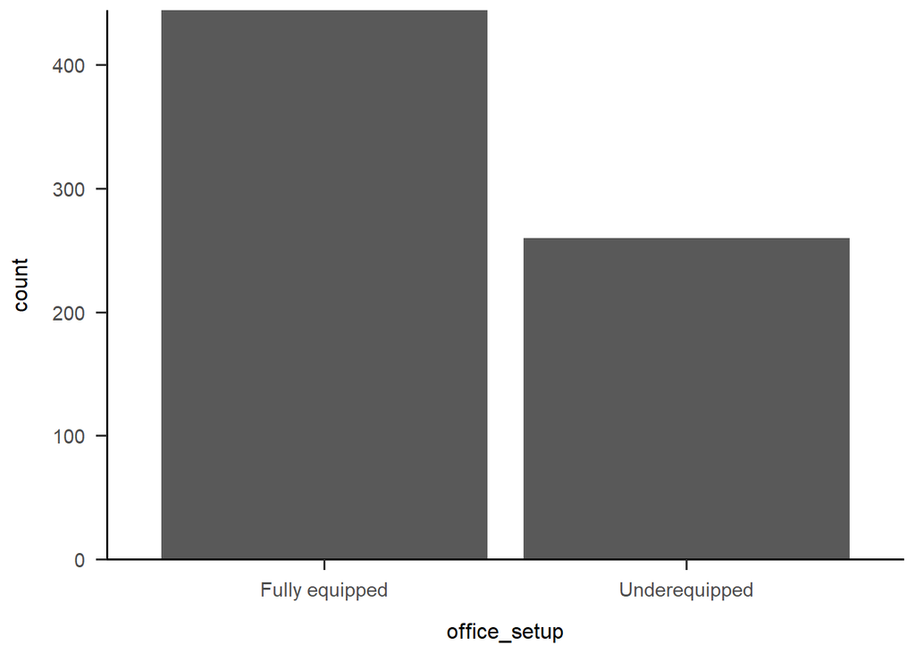

```r
apa_barplot(processed, office_setup)
```

## Living situation

```r
count(processed, living_sit)
```

```
## # A tibble: 7 x 2
##   living_sit                                            n
##   <chr>                                             <int>
## 1 Living alone                                         92
## 2 Living only with partner                            242
## 3 Living with non-family others                         8
## 4 Living with parents or other adult family members    25
## 5 Living with partner and non-adult child(ren)        281
## 6 Other                                                33
## 7 Single-parent with non-adult child(ren)              23
```

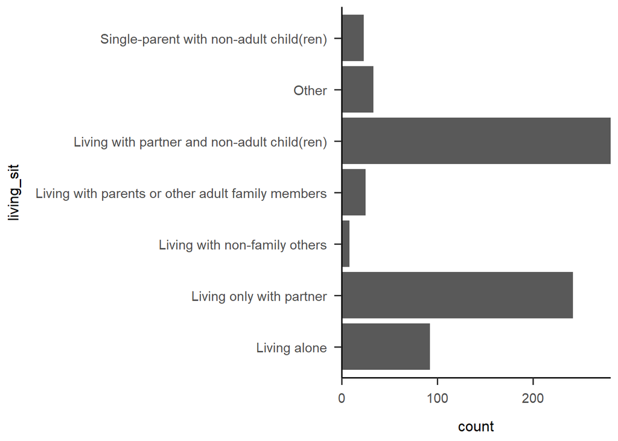

```r
apa_barplot(processed, living_sit) +
  coord_flip()
```

## Partner working from home during the pandemic

```r
count(processed, partner_work)
```

```
## # A tibble: 3 x 2
##   partner_work     n
##   <chr>        <int>
## 1 No             121
## 2 Yes            446
## 3 <NA>           137
```

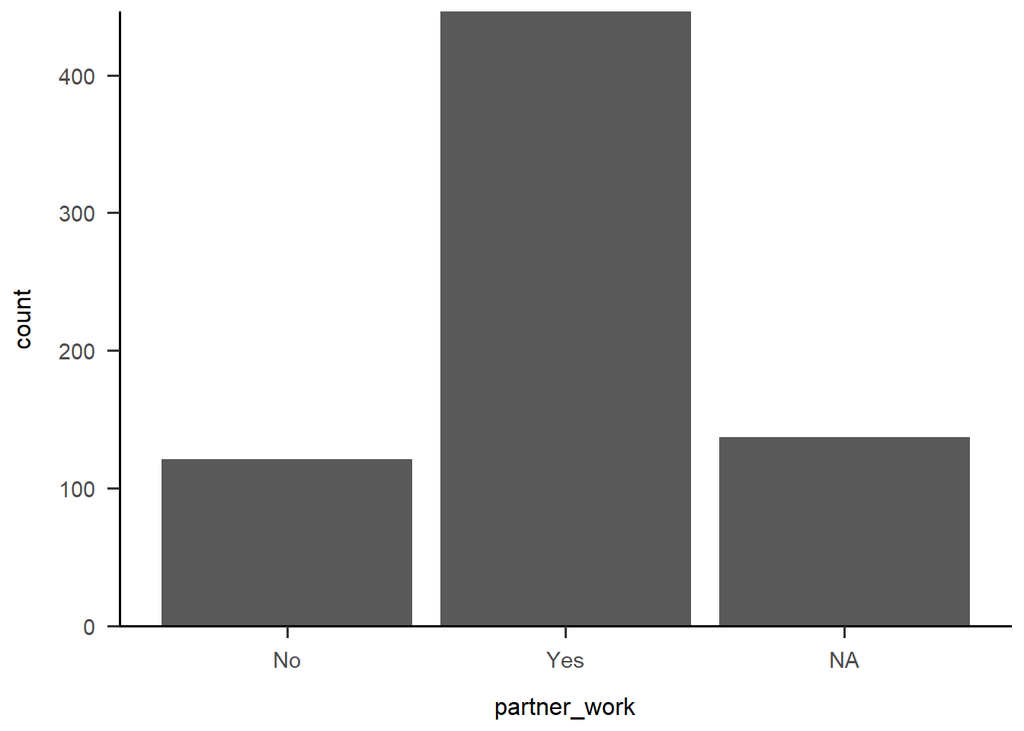

```r
apa_barplot(processed, partner_work)
```

## How far is the office from home

```r
count(processed, work_home_dist)
```

```
## # A tibble: 3 x 2
##   work_home_dist     n
##   <chr>          <int>
## 1 <30 min          419
## 2 >60 min           89
## 3 30-60 min        196
```

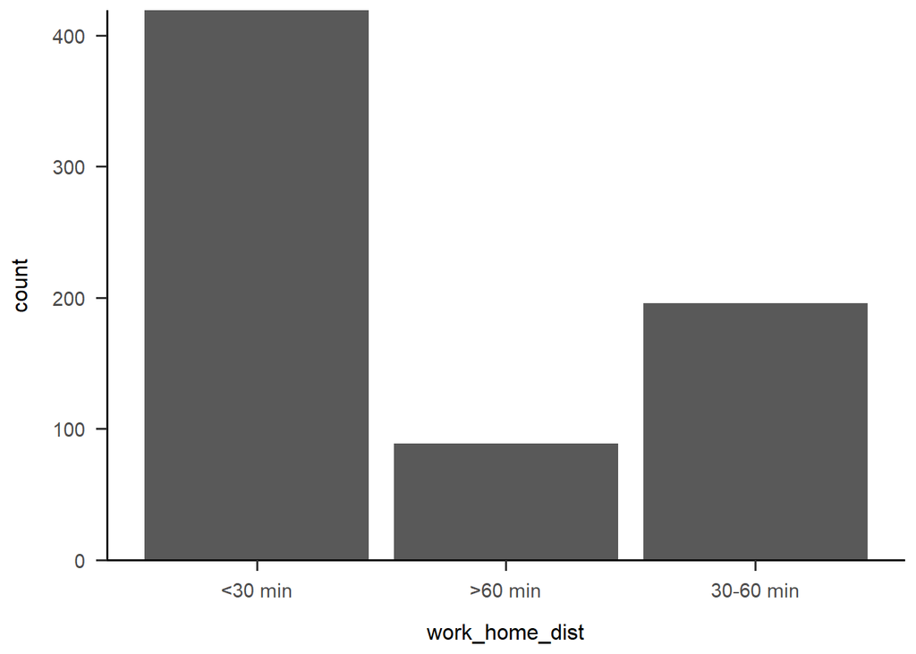

```r
apa_barplot(processed, work_home_dist)
```

## Number of children

```r
count(processed, number_of_children)
```

```
## # A tibble: 10 x 2
##    number_of_children     n
##                 <dbl> <int>
##  1                  0   358
##  2                  1   128
##  3                  2   163
##  4                  3    41
##  5                  4     7
##  6                  5     3
##  7                  7     1
##  8                  8     1
##  9                 12     1
## 10                 22     1
```

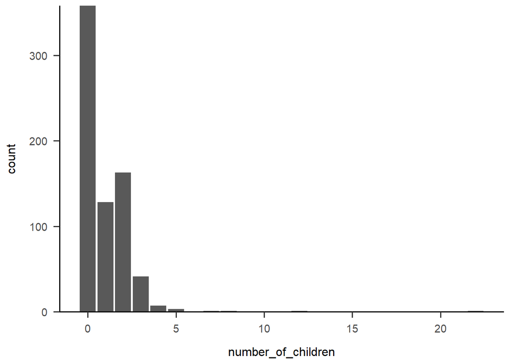

```r
apa_barplot(processed, number_of_children)
```

## Homeschooling during pandemic

```r
count(processed, homeschool)
```

```
## # A tibble: 2 x 2
##   homeschool     n
##   <chr>      <int>
## 1 No           465
## 2 Yes          239
```

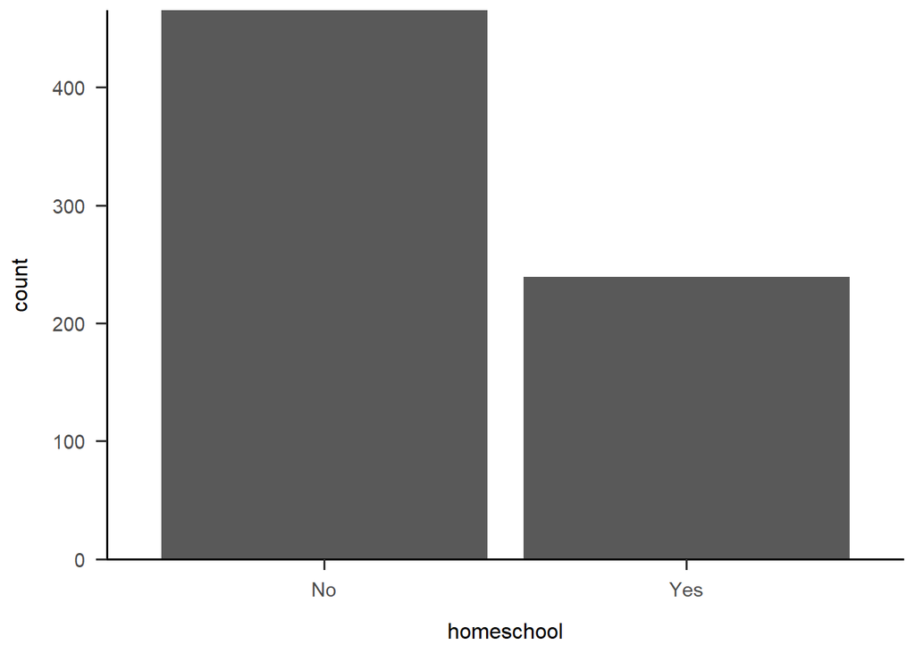

```r
apa_barplot(processed, homeschool)
```

## Help with children during pandemic

```r
count(processed, childcare_help)
```

```
## # A tibble: 3 x 2
##   childcare_help     n
##   <chr>          <int>
## 1 No               227
## 2 Yes              124
## 3 <NA>             353
```

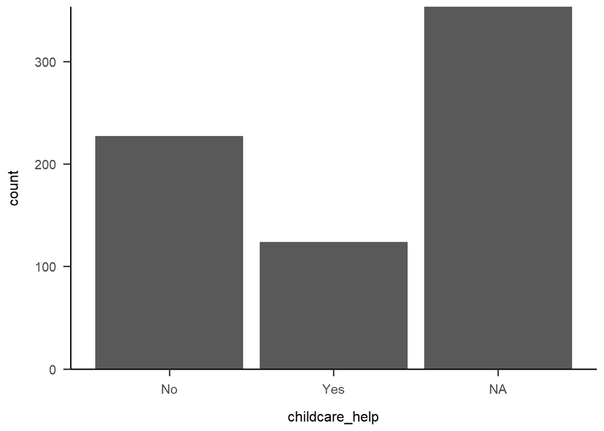

```r
apa_barplot(processed, childcare_help)
```

# Percentage of working more from home during the pandemic

```r
count(processed, working_home_time)
```

```
## # A tibble: 2 x 2
##   working_home_time     n
##   <chr>             <int>
## 1 No                   42
## 2 Yes                 662
```

# Efficiency of remore working

## During the lockdown

```r
processed %>%
  distinct(now_before_eff)
```

```
## # A tibble: 4 x 1
##   now_before_eff
##   <chr>
## 1 less efficient
## 2 more efficient
## 3 similarly efficient
## 4 <NA>
```

```r
now_before_eff <-
  processed %>%
  filter(!is.na(now_before_eff)) %>%
  count(now_before_eff) %>%
  mutate(N = sum(n),
         prop = round(n / N * 100, 2))
```

## After the lockdown

```r
processed %>%
  distinct(now_later_eff)
```

```
## # A tibble: 3 x 1
##   now_later_eff
##   <chr>
## 1 similarly efficient
## 2 more efficient
## 3 less efficient
```

```r
now_later_eff <-
  processed %>%
  filter(!is.na(now_later_eff)) %>%
  count(now_later_eff) %>%
  mutate(N = sum(n),
         prop = n / N * 100)
```

## Main advantages of working from home

We calculate the means and SDs of each aspects ratings. Aspects with higher rating than 4 indicates that it is better to do the task from the lab. Ratings with lower mean rating than 4 means that it is better to do the given action from home.

```r
aspects <-
    processed %>%
    select(participant_id, contains("home_office_aspect")) %>%
    gather(key = "aspect", value = "rating", -participant_id) %>%
    mutate(aspect = case_when(aspect == "home_office_aspect_1" ~ "Optimally organizing my time",
                              aspect == "home_office_aspect_2" ~ "Optimally organizing my tasks",
                              aspect == "home_office_aspect_3" ~ "Keeping focused on my tasks",
                              aspect == "home_office_aspect_4" ~ "Keeping in touch with my team",
                              aspect == "home_office_aspect_5" ~ "Sharing thoughts with colleagues",
                              aspect == "home_office_aspect_6" ~ "Getting support from colleagues",
                              aspect == "home_office_aspect_7" ~ "Working on my manuscript",
                              aspect == "home_office_aspect_8" ~ "Analyzing my data",
                              aspect == "home_office_aspect_9" ~ "Reading the literature",
                              aspect == "home_office_aspect_10" ~ "Collecting data",
                              aspect == "home_office_aspect_11" ~ "Having the infrastructure\n(IT, books, instruments)",
                              aspect == "home_office_aspect_12" ~ "Maintaining emotional balance",
                              aspect == "home_office_aspect_13" ~ "Maintaining work-life balance",
                              aspect == "home_office_aspect_14" ~ "Keeping good relationship\nwith colleagues",
                              aspect == "home_office_aspect_15" ~ "Developing new skills")) %>%
  group_by(aspect) %>%
  summarise(mean = mean(rating, na.rm = TRUE),
            sd = sd(rating, na.rm = TRUE)) %>%
  mutate(better_home = case_when(mean > 4 ~ 0L,
                                 mean < 4 ~ 1L,
                                 mean == 4 ~ NA_integer_)) %>%
  arrange(better_home, mean)
```

```r
aspects %>%
  filter(better_home == 1L) %>%
  slice_min(mean, n = 3)
```

```
## # A tibble: 3 x 4
##   aspect                    mean    sd better_home
##   <chr>                    <dbl> <dbl>       <int>
## 1 Working on my manuscript  3.00  1.89           1
## 2 Reading the literature    3.16  1.85           1
## 3 Analyzing my data         3.42  1.94           1
```

## Main advantages of working in the lab

The three highest-rated advantages of working from the lab

```r
aspects %>%
  filter(better_home == 0L) %>%
  slice_max(mean, n = 3)
```

```
## # A tibble: 3 x 4
##   aspect                            mean    sd better_home
##   <chr>                            <dbl> <dbl>       <int>
## 1 Sharing thoughts with colleagues  5.28  1.44           0
## 2 Keeping in touch with my team     5.22  1.42           0
## 3 Collecting data                   5.15  1.69           0
```

## How much did researchers work from home before the pandemic?

The distribution of percentages of working from your home time before the pandemic.

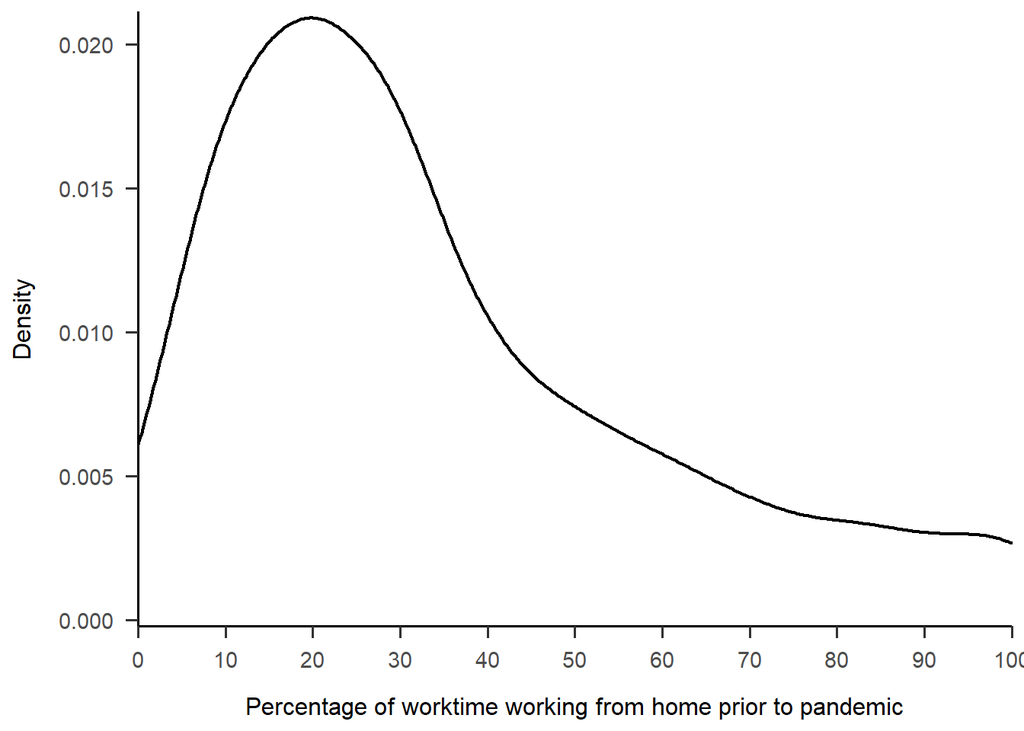

```r
percentage_plot_data <-
    processed %>%
    select(participant_id,
           prior_home_prop_1,
           future_home_prop_1) %>%
    gather(key = "time", value = "percent", -participant_id) %>%
    mutate(time = case_when(time == "prior_home_prop_1" ~ "Prior to pandemic",
                            time == "future_home_prop_1" ~ "Ideal"),
           time = factor(time, c("Prior to pandemic", "Ideal")))

percentage_plot_data %>%
  filter(time == "Prior to pandemic") %>%
  ggplot() +
  aes(x = percent) +
  geom_density(alpha = 0.6, size = 0.8) +
  scale_y_continuous(expand = c(0.01, 0),
                     breaks = scales::pretty_breaks()) +
  scale_x_continuous(expand = c(0, 0),
                     breaks = seq(0, 100, 10),
                     labels = seq(0, 100, 10)) +
  labs(x = "Percentage of worktime working from home prior to pandemic",
       y = "Density") +
  papaja::theme_apa()
```

## How much would researchers work from home after the pandemic?

The distribution of percentages of ideal working from home time after the pandemic.

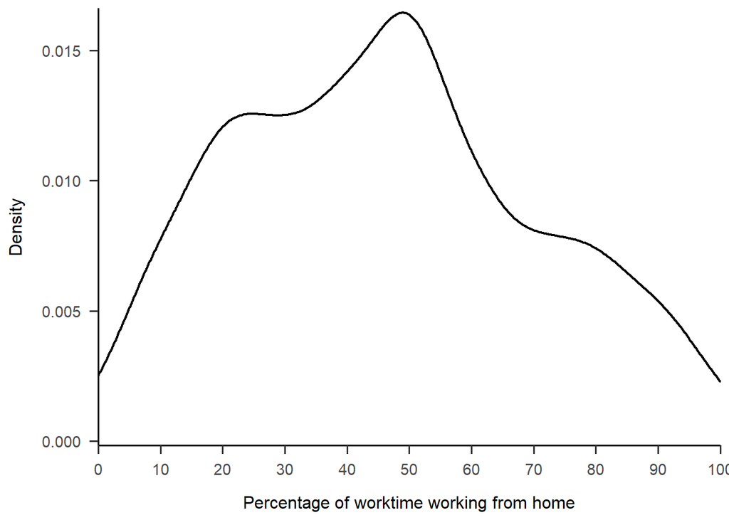

```r
percentage_plot_data %>%
  filter(time == "Ideal") %>%
  ggplot() +
  aes(x = percent) +
  geom_density(alpha = 0.6, size = 0.8) +
  scale_y_continuous(expand = c(0.01, 0),
                     breaks = scales::pretty_breaks()) +
  scale_x_continuous(expand = c(0, 0),
                     breaks = seq(0, 100, 10),
                     labels = seq(0, 100, 10)) +
  labs(x = "Percentage of worktime working from home",
       y = "Density") +
  papaja::theme_apa()
```

Prior and ideal percentages of working from home on the smae figure.

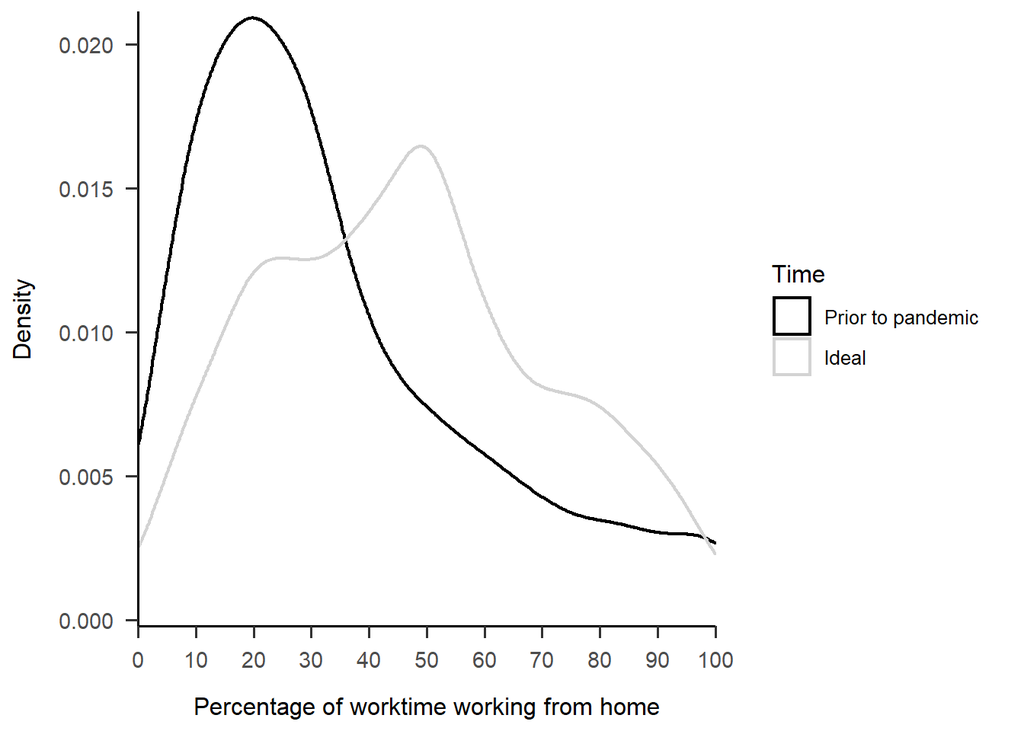

```r
percentage_plot_data %>%
  ggplot() +
  aes(x = percent,
      color = time) +
  geom_density(alpha = 0.6, size = 0.8) +
  scale_y_continuous(expand = c(0.01, 0),
                     breaks = scales::pretty_breaks()) +
  scale_x_continuous(expand = c(0, 0),
                     breaks = seq(0, 100, 10),
                     labels = seq(0, 100, 10)) +
  scale_fill_manual(values = c('#000000', '#D3D3D3')) +
  scale_color_manual(values=c('#000000', '#D3D3D3'))+
  labs(x = "Percentage of worktime working from home",
       y = "Density",
       color = "Time") +
  papaja::theme_apa()
```

## Would it be possible to work more from home in the future?

See the distinct values of the difference between the ideal percentage of working more from the future and the prior percentage. If the difference is negative the respondent wants to work less from home in the future, if it is positive the respondents wants to work more from home in the future.

```r
processed %>%
  distinct(future_prior_diff) %>%
  arrange(future_prior_diff)
```

```
## # A tibble: 99 x 1
##    future_prior_diff
##                <dbl>
##  1               -85
##  2               -80
##  3               -75
##  4               -70
##  5               -65
##  6               -60
##  7               -58
##  8               -51
##  9               -50
## 10               -42
## # ... with 89 more rows
```

Showing a descriptive comparison.

```r
processed %>%
  mutate(more_from_home = case_when(future_prior_diff > 0 ~ "Respondent wants to work more from home",
                                    future_prior_diff < 0 ~ "Respondent wants to work less from home",
                                    future_prior_diff == 0 ~ "Respondent working the ideal amount of time from home")) %>%
  count(more_from_home) %>%
  mutate(N = sum(n),
         prop = n / N * 100) %>%
  arrange(n)
```

```
## # A tibble: 3 x 4
##   more_from_home                                            n     N  prop
##   <chr>                                                 <int> <int> <dbl>
## 1 Respondent wants to work less from home                 114   704  16.2
## 2 Respondent working the ideal amount of time from home   129   704  18.3
## 3 Respondent wants to work more from home                 461   704  65.5
```

Number of respondents who worked 100% from home before the pandemic.

```r
processed %>%
  filter(prior_home_prop_1 == 100) %>%
  count()
```

```
## # A tibble: 1 x 1
##       n
##   <int>
## 1    20
```

```r
processed %>%
  filter(prior_home_prop_1 != 100,
         future_prior_diff > 0,
         now_later_eff == "more efficient") %>%
  count(feasible) %>%
  mutate(N = sum(n),
         prop = n / N * 100)
```

```
## # A tibble: 2 x 4
##   feasible     n     N  prop
##   <chr>    <int> <int> <dbl>
## 1 No          15   172  8.72
## 2 Yes        157   172 91.3
```

## Additional analyses

Additional descriptive results will be provided for the interested subgroups. Our interested subgroups will be primarily those relevant to the following questions:

### Are people living with children more or less efficient when working from home?

```r
processed %>% distinct(living_sit)
```

```
## # A tibble: 7 x 1
##   living_sit
##   <chr>
## 1 Living only with partner
## 2 Living with partner and non-adult child(ren)
## 3 Living alone
## 4 Other
## 5 Living with parents or other adult family members
## 6 Single-parent with non-adult child(ren)
## 7 Living with non-family others
```

```r
living_sit_include <- c("Living with partner and non-adult child(ren)", "Single-parent with non-adult child(ren)")
```

Number of kids in this subsample.

```r
processed %>%
  filter(living_sit %in% living_sit_include) %>%
  select(number_of_children) %>%
  arrange(number_of_children)
```

```
## # A tibble: 304 x 1
##    number_of_children
##                 <dbl>
##  1                  0
##  2                  1
##  3                  1
##  4                  1
##  5                  1
##  6                  1
##  7                  1
##  8                  1
##  9                  1
## 10                  1
## # ... with 294 more rows
```

```r
processed %>%
  filter(living_sit %in% living_sit_include,
         !is.na(now_before_eff)) %>%
  count(now_before_eff) %>%
  mutate(N = sum(n),
         prop = round(n / N * 100, 2))
```

```
## # A tibble: 3 x 4
##   now_before_eff          n     N  prop
##   <chr>               <int> <int> <dbl>
## 1 less efficient        168   290  57.9
## 2 more efficient         57   290  19.7
## 3 similarly efficient    65   290  22.4
```

### What circumstances make a researcher with children more or less efficient in working from home during and after the lockdown?

We need to talk about this.

### Which subgroup would benefit the most/less from working more from home? [interested factors: seniority, data collection method]

We need to talk about this.

### Would it be ideal and possible for those with teaching duties to work proportionally more from home in the future than before the pandemic?

Would it be possible?

```r
processed %>%
  filter(edu_duties == "Yes") %>%
  count(feasible) %>%
  mutate(N = sum(n),
         prop = round(n / N * 100, 2))
```

```
## # A tibble: 2 x 4
##   feasible     n     N  prop
##   <chr>    <int> <int> <dbl>
## 1 No         131   566  23.1
## 2 Yes        435   566  76.9
```

Would it be ideal?

```r
processed %>%
  filter(edu_duties == "Yes") %>%
  mutate(more_from_home = case_when(future_prior_diff > 0 ~ "Respondent wants to work more from home",
                                    future_prior_diff < 0 ~ "Respondent wants to work less from home",
                                    future_prior_diff == 0 ~ "Respondent working the ideal amount of time from home")) %>%
  count(more_from_home) %>%
  mutate(N = sum(n),
         prop = n / N * 100)
```

```
## # A tibble: 3 x 4
##   more_from_home                                            n     N  prop
##   <chr>                                                 <int> <int> <dbl>
## 1 Respondent wants to work less from home                  84   566  14.8
## 2 Respondent wants to work more from home                 376   566  66.4
## 3 Respondent working the ideal amount of time from home   106   566  18.7
```